# Migración y escolaridad incompleta en adultos para la Región Metropolitana

Alfonso Morales Donoso

2025-10-18

# 1. Introducción

Históricamente siempre ha existido población migrante la cual, por diversas circunstancias, ha tenido que migrar y buscar residencia fuera de su país de origen, lo que genera un cambio tanto para la persona al tener que adaptarse a las culturas de un nuevo país, como para el país al tener que adaptarse al ingreso de diferentes culturas.

En este siglo, Chile ha presentado en los últimos 20 años un crecimiento de esta población migrante que ha ido cada vez en aumento, ya sea por diversas crisis económicas y sociales presentes en sus países de origen. Esto ha generado una sobrepoblación en ciertos sectores del país, con problemáticas de saturación de sistemas de salud, educación, seguridad y un déficit habitacional aún más grande del que ya existía.

Más allá de los desafíos visibles como la vivienda o la salud, resulta crucial abordar la dimensión educativa. Esta área a menudo es objeto de una fuerte estigmatización social, debido a la percepción que suele vincular un bajo nivel educativo con un supuesto incremento de la delincuencia. Por esta razón, el presente análisis priorizará el estudio de la escolaridad incompleta en la población migrante adulta que reside en la provincia de Santiago.

## 1.1. Objetivo general

Analizar la prevalencia de la escolaridad incompleta en la población migrante mayor de 18 años, residente en la Región Metropolitana.

## 1.2. Objetivos específicos

- Calcular a escala de zona censal, el porcentaje de la población migrante adulta y el porcentaje de migrantes adultos con escolaridad incompleta.
- Examinar la correlación entre estos indicadores.
- Representar espacialmente la distribución de ambos indicadores y visualizarlo en un mapa bivariado.

# 2. Desarrollo

## 2.1. Metodología

Para llevar a cabo el presente análisis, se adoptó un enfoque cuantitativo y geoespacial, utilizando como fuente principal los datos censales del año 2017. El área de estudio es la provincia de Santiago junto a las comunas de San Bernardo y Puente Alto.

El procesamiento de los datos se realizó mediante la utilización de dos softwares:

1. **PGAdmin**:  
   En este software se trataron los datos mediante consultas SQL, donde se filtró y se agregó la información a nivel de zona censal, centrándose en la población migrante mayor de 18 años y la variable de escolaridad incompleta.
2. **RStudio**:  
   Aquí, los datos previamente tratados en PGAdmin se analizaron estadísticamente para la generación de todas las visualizaciones, incluyendo los mapas temáticos y el análisis de correlación.

## 2.1.1. Librerías necesarias

```r
library(DBI)
library(RPostgres)
library(sf)
library(ggplot2)
library(RColorBrewer)
library(cowplot)
library(biscale)
```

## 2.1.2. Conexión a la base de datos PostgreSQL

Los datos brutos del Censo 2017 se encontraban alojados en una base de datos relacional PostgreSQL con su extensión espacial PostGIS. El primer paso metodológico fue establecer una conexión desde R a dicha base de datos.

Mediante la función `dbConnect`, se especificaron las credenciales de acceso, lo que permitió interactuar con los datos de manera remota. Este método posibilitó la ejecución de consultas SQL complejas directamente desde el script, procesando los datos en el servidor para luego importar a R únicamente los resultados agregados a nivel de zona censal.

## 2.1.3. Indicadores

Las variables consideradas para la creación de los indicadores fueron:

- **p.p12**: Comuna o País de Nacimiento.
- **p.p09**: Edad.
- **p.p15**: Nivel del Curso Más Alto Aprobado.

El foco principal del análisis fue la creación de dos indicadores a nivel de la zona censal urbana, los cuales fueron calculados mediante consultas SQL que contenían información de las tablas de personas, viviendas y hogares.

#### a. Porcentaje de población migrante adulta

Mide el grado de concentración de la población migrante en cada zona.

**Fórmula:**

$$\text{Porcentaje de migrantes adultos} = \left( \frac{\text{Total de
migrantes > 18 años}}{\text{Total de personas > 18 años}} \right)
* 100$$

#### b. Porcentaje de población migrante adulta con escolaridad incompleta

**Fórmula:**

$$\text{Porcentaje de migrantes adultos con escolaridad incompleta} =
\left( \frac{\text{Total de migrantes > 18 con escolaridad <
8}}{\text{Total de migrantes > 18}} \right) * 100$$

### 2.1.4. Visualización

- Grafico de dispersión: muestra la correlación entre los dos indicadores ptje_migrantes_adultos (eje X) y ptje_esc_inc_mig_adultos (eje Y), además de mostrar la línea de tendencia para ver si la relación es positiva o negativa.
- Mapa univariado: Esta muestra la distribución espacial de cada indicador por separado.
- Mapa Bivariado: Este grafico combina ambos indicadores en un solo mapa. Donde este representa simultáneamente por colores el valor de cada indicador por cada zona censal.

## 2.2. Análisis y resultados

### 2.2.1 Gráfico de dispersión

El grafico muestra algo interesante que es la existencia de una correlación negativa, la línea de tendencia naranja va descendiendo, que indica que a medida el porcentaje de población migrante adulta representada en el eje X, tiene a disminuir el porcentaje de esos migrantes que tiene una escolaridad incompleta en el eje Y.

Este resultado es muy revelador debido a que confronta la estigmatización social presentada en la introducción, la cual suele asociar una alta presencia de migración con indicadores de precariedad, como lo es el bajo nivel educativo.

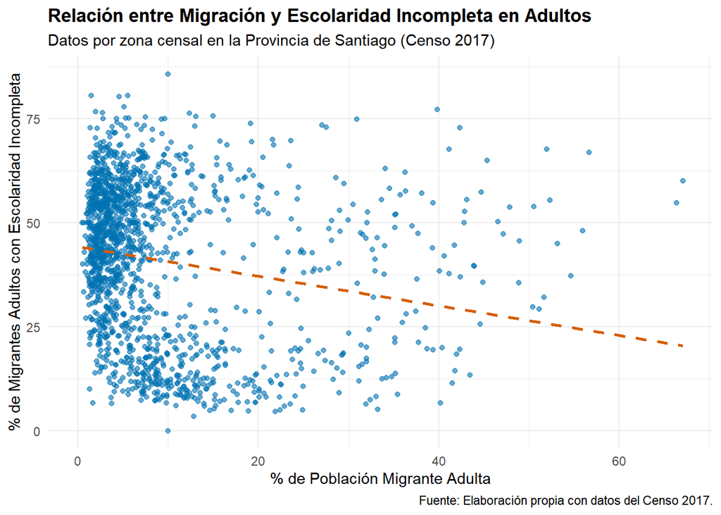

### 2.2.2 Mapa 1: Distribución de la Población Migrante Adulta

El primer mapa que es el porcentaje de migrantes adultos, mostro que el patrón es de alta concentración en el centro de la provincia de Santiago.

Las zonas censales con los porcentajes más altos de población migrante (colores amarillos y verdes claros, >40%) se agrupan de manera compacta en las comunas centrales, como Santiago, Estación Central, Independencia y Recoleta. Este patrón de “centro-periferia” es claro: la concentración de migrantes disminuye drásticamente a medida que nos alejamos de este núcleo, con las zonas periféricas de la provincia (como Puente Alto y San Bernardo) mostrando niveles mucho más bajos (colores morados oscuros, <10%). Esto sugiere que el centro de la ciudad actúa como el principal polo de atracción y residencia para la población migrante adulta.

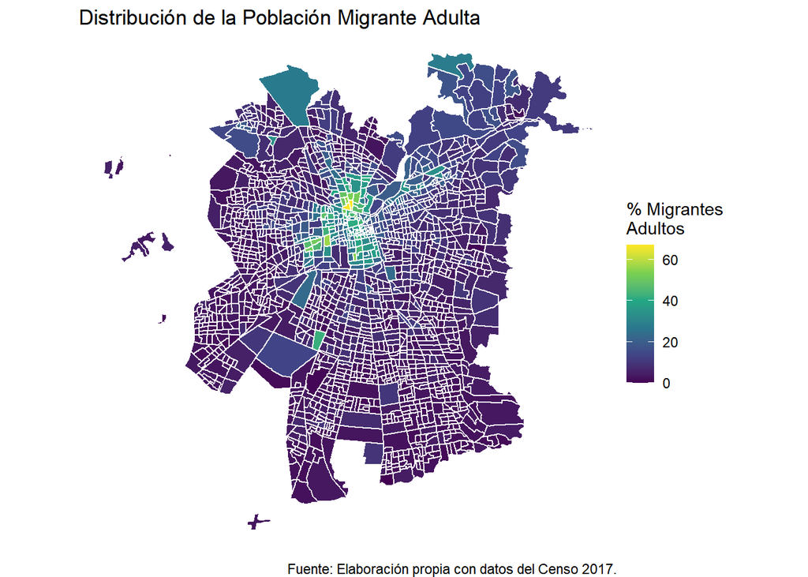

### 2.2.3. Mapa 2: Escolaridad Incompleta en Migrantes Adultos

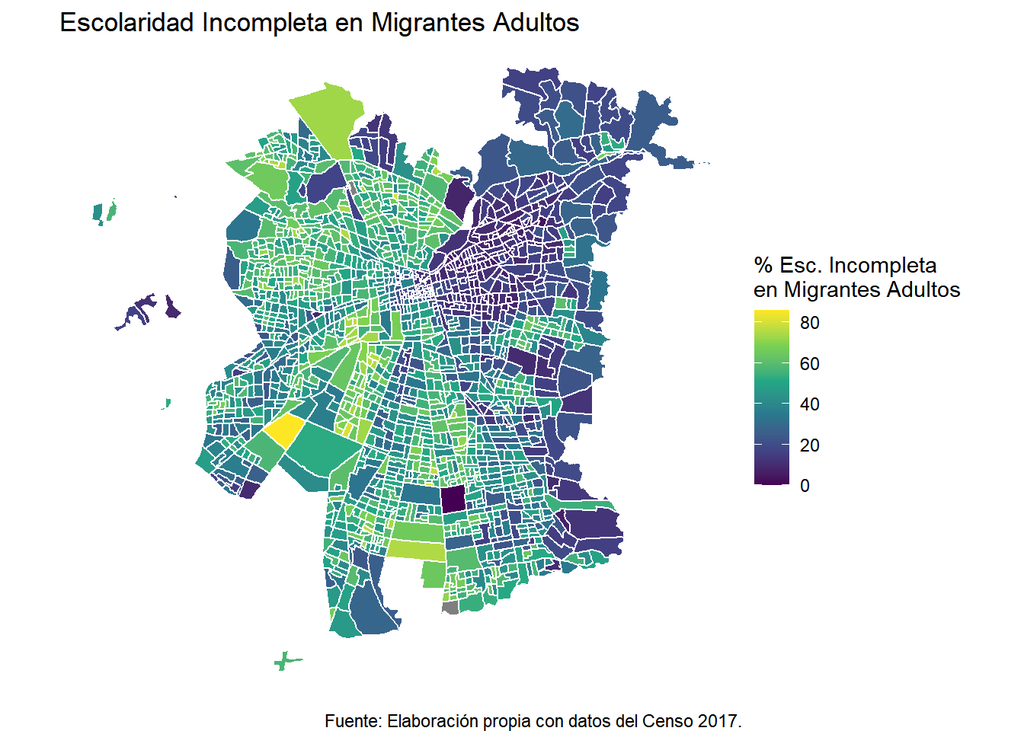

## Comparativa de Migración y Escolaridad

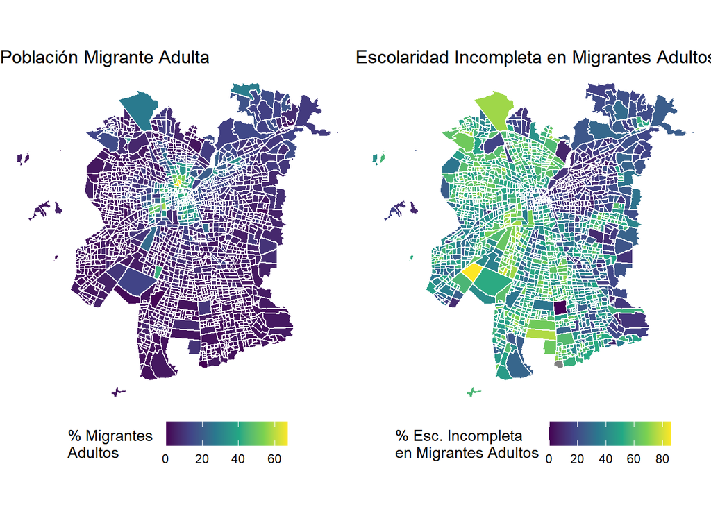